# Praca domowa 1

Martyna Majchrzak

9 03 2020

## Dataset

Information about patients from the Cleveland hospital being diagnosed with heart disease.

Columns:

- age - age of patient
- sex - 1=male; 0=female
- cp - chest pain type: 1=typical angina; 2=atypical angine; 3=non-anginal pain; 4=asymptomatic
- trestbps - resting blood pressure (mm Hg)
- chol - serum cholestrol (mg/dl)
- fbs - fasting blood sugar: 1 if > 120 mg/dl; 0 otherwise
- restecg - resting electrocardiographic results: 0=normal; 1=having ST-T wave abnormality; 2=showing probable or definite left ventricular hypertrophy
- thalach - maximum heart rate achieved
- exang - exercise induced angina: 1=yes; 0=no
- oldpeak - ST depression induced by exercise relative to rest
- slope - the slope of the peak exercise ST segment: 1=upsloping; 2=flat; 3=downsloping
- ca - number of major vessels (0-3) colored by flourosopy
- thal - 3=normal; 6=fixed defect; 7=reversable defect
- [target] num - 0-HEART DISEASE, 1-NO HEART DISEASE)

```r
head(data)
```

```
##   age sex cp trestbps chol fbs restecg thalach exang oldpeak slope ca thal num
## 1  63   1  1      145  233   1       2     150     0     2.3     3  0    6   0
## 2  67   1  4      160  286   0       2     108     1     1.5     2  3    3   1
## 3  67   1  4      120  229   0       2     129     1     2.6     2  2    7   1
## 4  37   1  3      130  250   0       0     187     0     3.5     3  0    3   0
## 5  41   0  2      130  204   0       2     172     0     1.4     1  0    3   0
## 6  56   1  2      120  236   0       0     178     0     0.8     1  0    3   0
```

```r
summary(data)
```

```
##       age             sex               cp           trestbps
##  Min.   :29.00   Min.   :0.0000   Min.   :1.000   Min.   : 94.0
##  1st Qu.:48.00   1st Qu.:0.0000   1st Qu.:3.000   1st Qu.:120.0
##  Median :56.00   Median :1.0000   Median :3.000   Median :130.0
##  Mean   :54.44   Mean   :0.6799   Mean   :3.158   Mean   :131.7
##  3rd Qu.:61.00   3rd Qu.:1.0000   3rd Qu.:4.000   3rd Qu.:140.0
##  Max.   :77.00   Max.   :1.0000   Max.   :4.000   Max.   :200.0
##       chol            fbs            restecg          thalach
##  Min.   :126.0   Min.   :0.0000   Min.   :0.0000   Min.   : 71.0
##  1st Qu.:211.0   1st Qu.:0.0000   1st Qu.:0.0000   1st Qu.:133.5
##  Median :241.0   Median :0.0000   Median :1.0000   Median :153.0
##  Mean   :246.7   Mean   :0.1485   Mean   :0.9901   Mean   :149.6
##  3rd Qu.:275.0   3rd Qu.:0.0000   3rd Qu.:2.0000   3rd Qu.:166.0
##  Max.   :564.0   Max.   :1.0000   Max.   :2.0000   Max.   :202.0
##      exang           oldpeak         slope             ca
##  Min.   :0.0000   Min.   :0.00   Min.   :1.000   Min.   :0.0000
##  1st Qu.:0.0000   1st Qu.:0.00   1st Qu.:1.000   1st Qu.:0.0000
##  Median :0.0000   Median :0.80   Median :2.000   Median :0.0000
##  Mean   :0.3267   Mean   :1.04   Mean   :1.601   Mean   :0.6634
##  3rd Qu.:1.0000   3rd Qu.:1.60   3rd Qu.:2.000   3rd Qu.:1.0000
##  Max.   :1.0000   Max.   :6.20   Max.   :3.000   Max.   :3.0000
##       thal            num
##  Min.   :0.000   Min.   :0.0000
##  1st Qu.:3.000   1st Qu.:0.0000
##  Median :3.000   Median :0.0000
##  Mean   :4.703   Mean   :0.4587
##  3rd Qu.:7.000   3rd Qu.:1.0000
##  Max.   :7.000   Max.   :1.0000
```

## Data Explorer

#### Density

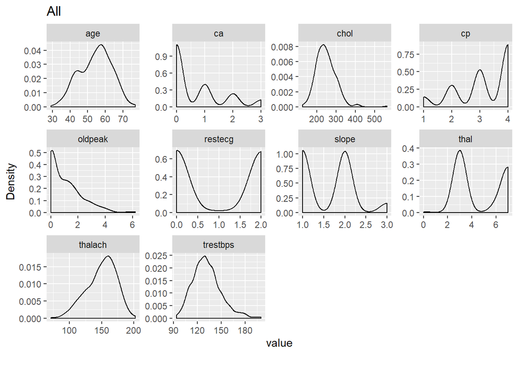

```r
DataExplorer::plot_density(data, title="All")
```

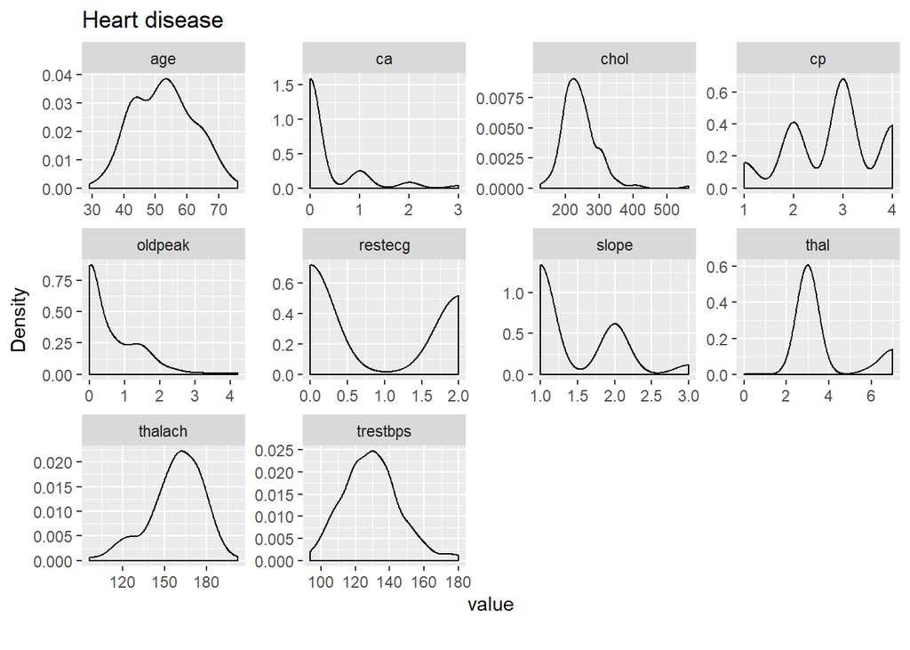

```r
DataExplorer::plot_density(data%>%filter(num==0), title="Heart disease")
```

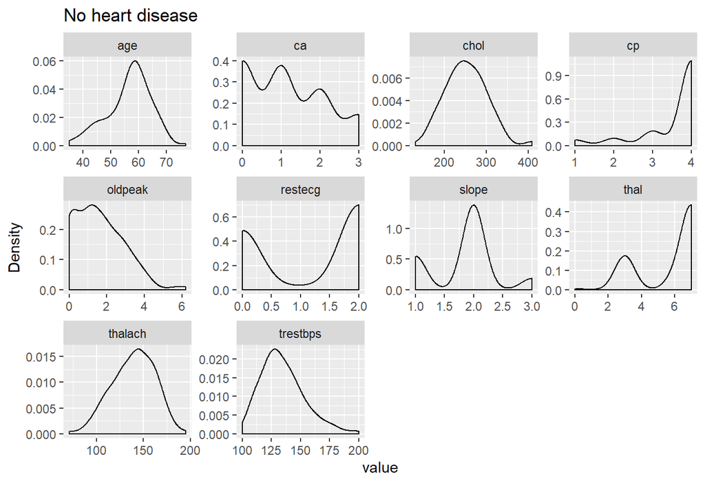

```r
DataExplorer::plot_density(data%>%filter(num==1), title="No heart disease")
```

Patients with heart disease are much more common to have non-anginal chest pain (3), where patients without hearts disease often have asymptomatic chest pain (4).

#### Boxplots

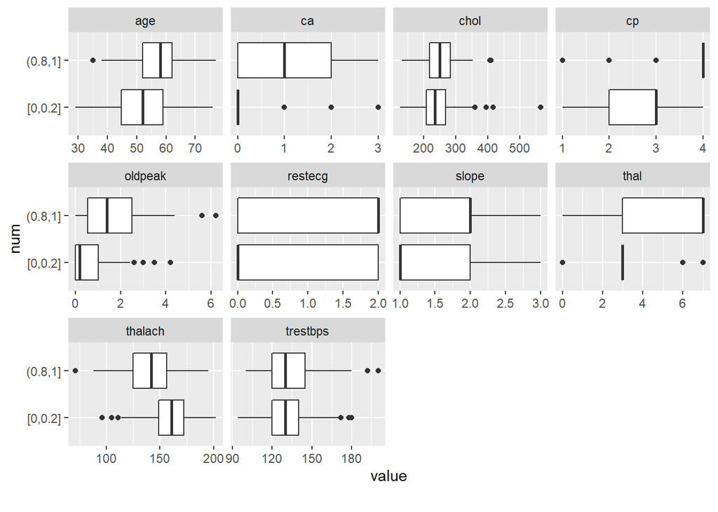

```r
DataExplorer::plot_boxplot(data, by = "num")
```

Patients with heart disease have slighty maximum heart rate achieved (thalach) than those without.

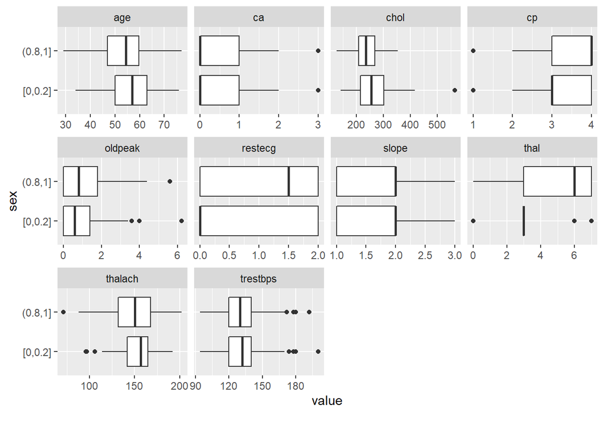

```r
DataExplorer::plot_boxplot(data, by = "sex")
```

Women have slighty higher maximum heart rate achieved (thalach) and cholesterol (ch) than man,

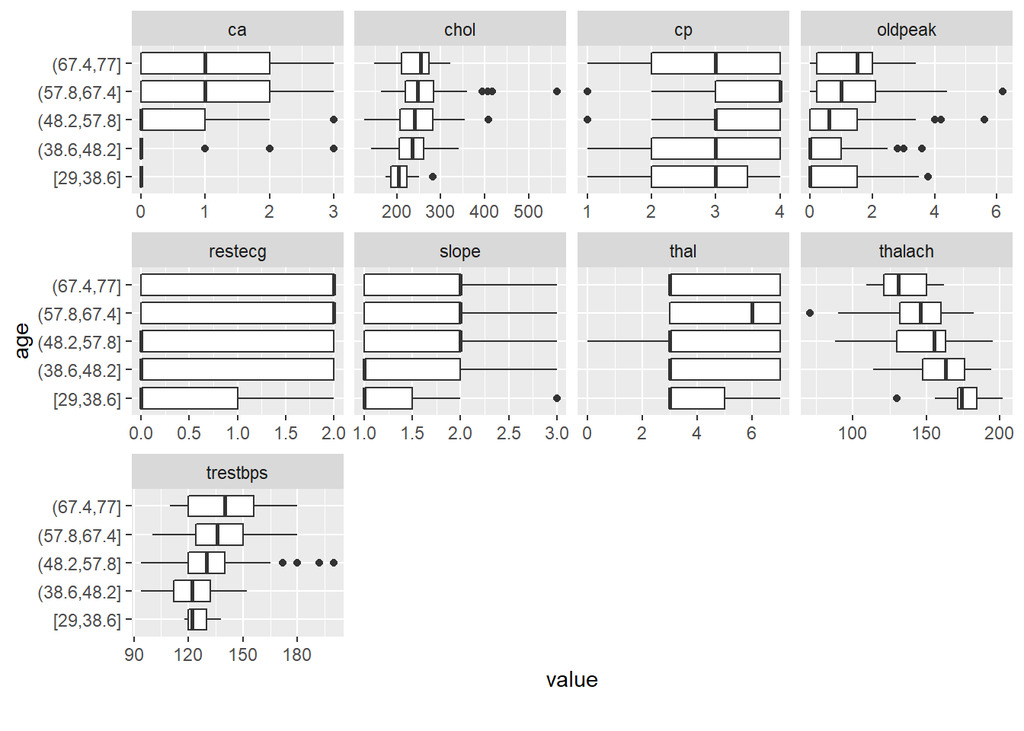

```r
DataExplorer::plot_boxplot(data, by = "age")
```

Resting blood pressure (trestbps) is increasing with age, but maximum heart rate (thalach) dicreases.

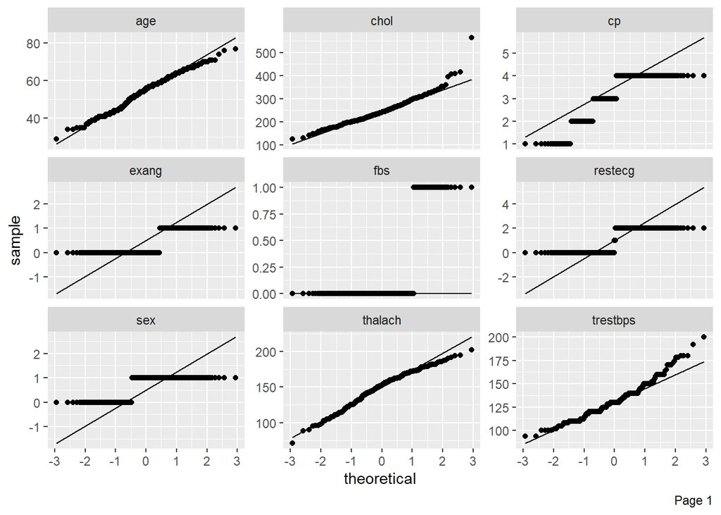

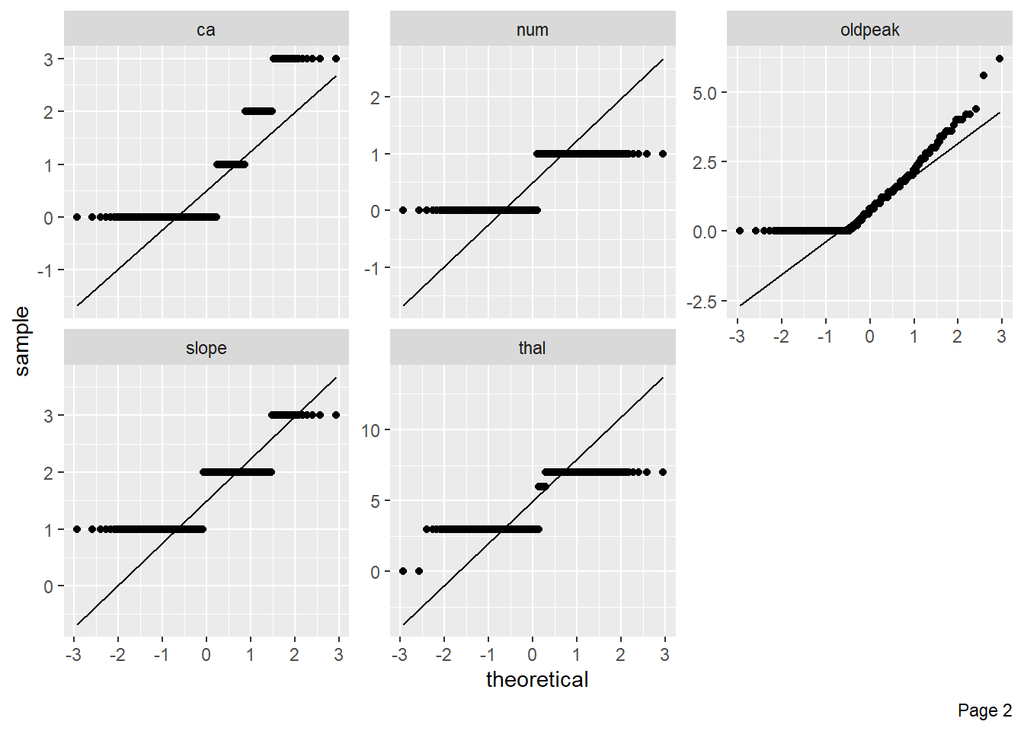

```r
DataExplorer::plot_qq(data)
```

#### Correlation

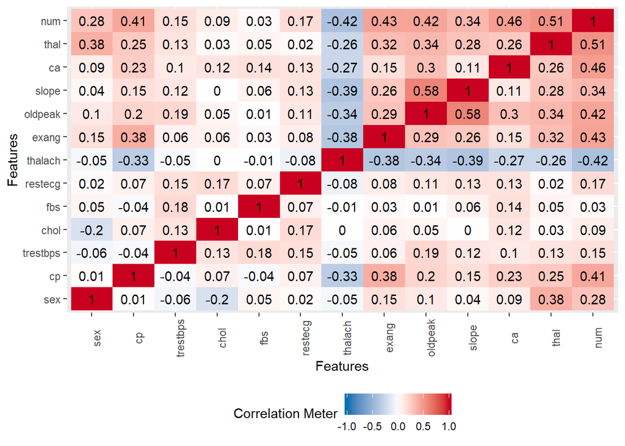

```r
DataExplorer::plot_correlation(data[,-1])
```